# 03 Caching `SpaDES` simulations

Eliot J. B. McIntire

September 02 2025

As part of a reproducible work flow, caching of various function calls are a critical component. Down the road, it is likely that an entire work flow from raw data to publication, decision support, report writing, presentation building etc., could be built and be reproducible anywhere, on demand. The `reproducible::Cache` function is built to work with any R function. However, it becomes very powerful in a `SpaDES` context because we can build large, powerful applications that are transparent and tied to the raw data that may be *many* conceptual steps upstream in the workflow. To do this, we have built several customizations within the `SpaDES` package. Important to this is dealing correctly with the `simList`, which is an object that has slot that is an environment. But more important are the various tools that can be used at higher levels, *i.e.*, not just for “standard” functions.

# 1 Caching as part of `SpaDES`

Some of the details of the `simList`-specific features of this `Cache` function include:

- The function converts all elements that have an environment as part of their attributes into a format that has no unique environment attribute, using `format` if a function, and `as.list` in the case of the `simList` environment.
- When used within `SpaDES` modules, `Cache` (capital C) does not require that the argument `cachePath` be specified. If called from inside a SpaDES module, `Cache` will use the `cachePath` argument from a call to `cachePath(sim)`, taking the `sim` from the call stack. Similarly, if no `cachePath` argument is specified, then it will use `getOption("spades.cachePath")`, which will, by default, be a temporary location with no persistence between R sessions! To persist between sessions, use `SpaDES::setPaths()` every session.

In a `SpaDES` context, there are several levels of caching that can be used as part of a reproducible workflow. Each level can be used to a modeller’s advantage; and, all can be – and are often – used concurrently.

## 1.1 At the `spades` level

And entire call to `spades` can be cached. This will have the effect of eliminating any stochasticity in the model as the output will simply be the cached version of the `simList`. This is likely most useful in situations where reproducibility is more important than “new” stochasticity (*e.g.*, building decision support systems, apps, final version of a manuscript).

```r
library(terra)
library(reproducible)
library(SpaDES.core)

mySim <- simInit(
  times = list(start = 0.0, end = 3.0),
  params = list(
    .globals = list(stackName = "landscape", burnStats = "testStats"),
    randomLandscapes = list(.plotInitialTime = NA),
    fireSpread = list(.plotInitialTime = NA)
  ),
  modules = list("randomLandscapes", "fireSpread"),
  paths = list(modulePath = getSampleModules(tempdir()))
)
```

This functionality can be achieved within a `spades` call.

```r
# compare caching ... run once to create cache
system.time({
  outSim <- spades(Copy(mySim), cache = TRUE, notOlderThan = Sys.time())
})
```

```
## Sep02 12:26:48 simInit Using setDTthreads(1). To change: 'options(spades.DTthreads = X)'.
```

```
## Sep02 12:26:48 chckpn:init total elpsd: 0.077 secs | 0 checkpoint init 0
```

```
## Sep02 12:26:48 save  :init total elpsd: 0.079 secs | 0 save init 0
```

```
## Sep02 12:26:48 prgrss:init total elpsd: 0.081 secs | 0 progress init 0
```

```
## Sep02 12:26:48 load  :init total elpsd: 0.084 secs | 0 load init 0
```

```
## Sep02 12:26:48 rndmLn:init total elpsd: 0.086 secs | 0 randomLandscapes init
```

```
## Sep02 12:26:48 rndmLn:init New objects created:
```

```
## Sep02 12:26:48 rndmLn:init <char>
## Sep02 12:26:48 rndmLn:init  1:  landscape
```

```
## Sep02 12:26:48 frSprd:init total elpsd: 0.2 secs | 0 fireSpread init 1
```

```
## Sep02 12:26:48 frSprd:init fireSpread
```

```
## Sep02 12:26:48 frSprd:init New objects created:
```

```
## Sep02 12:26:48 frSprd:init <char>
## Sep02 12:26:48 frSprd:init  1:  testStats
```

```
## Sep02 12:26:48 frSprd:burn total elpsd: 0.23 secs | 1 fireSpread burn 5
```

```
## Sep02 12:26:48 frSprd:stats total elpsd: 0.27 secs | 1 fireSpread stats 5
```

```
## Sep02 12:26:48 frSprd:stats fireSpread
```

```
## Sep02 12:26:48 frSprd:burn total elpsd: 0.27 secs | 2 fireSpread burn 5
```

```
## Sep02 12:26:48 frSprd:stats total elpsd: 0.3 secs | 2 fireSpread stats 5
```

```
## Sep02 12:26:48 frSprd:stats fireSpread
```

```
## Sep02 12:26:48 frSprd:burn total elpsd: 0.31 secs | 3 fireSpread burn 5
```

```
## Sep02 12:26:48 frSprd:stats total elpsd: 0.34 secs | 3 fireSpread stats 5
```

```
## Sep02 12:26:48 frSprd:stats fireSpread
```

```
## simList saved in
## SpaDES.core:::savedSimEnv()$.sim
## It will be deleted at next spades() call.
```

```
## Saving large object (fn: spades , cacheId: f0413b6e4b5b05a7 ) to Cache : 10.6
##   Mb
```

```
##  Done!
```

```
## Saved! Cache file: f0413b6e4b5b05a7.rds; fn: spades
```

```
##    user  system elapsed
##   2.052   0.188   2.253
```

Note that if there were any visualizations (here we turned them off with `.plotInitialTime = NA` above) they will happen the first time through, but not the cached times.

```r
# faster 2nd time
system.time({
  outSimCached <- spades(Copy(mySim), cache = TRUE)
})
```

```
## Object to retrieve (fn: spades, f0413b6e4b5b05a7.rds) ...
```

```
## Loaded! Cached result from previous spades call
```

```
## from  module
```

```
##    user  system elapsed
##   0.965   0.004   0.973
```

```r
all.equal(outSim, outSimCached)
```

```
## [1] "Names: 2 string mismatches"
## [2] "Length mismatch: comparison on first 3 components"
## [3] "Component 2: Modes: numeric, NULL"
## [4] "Component 2: Lengths: 4, 0"
## [5] "Component 2: target is numeric, current is NULL"
## [6] "Component 3: target is NULL, current is PackedSpatRaster"
```

## 1.2 Module-level caching

If the parameter `.useCache` in the module’s metadata is set to `TRUE`, then *every* event in the module will be cached. That means that every time that module is called from within a `spades()` call, `Cache` will be called. Only the objects inside the `simList` that correspond to the `inputObjects` or the `outputObjects` from the module metadata will be assessed for caching. For general use, module-level caching would be mostly useful for modules that have no stochasticity, such as data-preparation modules, GIS modules etc.

In this example, we will use the cache on the `randomLandscapes` module. This means that each subsequent call to spades will result in identical outputs from the `randomLandscapes` module (only!). This would be useful when only one random landscape is needed simply for trying something out, or putting into production code (*e.g.*, publication, decision support, etc.).

```r
# Module-level
params(mySim)$randomLandscapes$.useCache <- TRUE
system.time({
  randomSim <- spades(Copy(mySim), .plotInitialTime = NA,
                      notOlderThan = Sys.time(), debug = TRUE)
})
```

```
## Sep02 12:26:51 simInit Using setDTthreads(1). To change: 'options(spades.DTthreads = X)'.
```

```
## Sep02 12:26:51 chckpn:init eventTime moduleName eventType eventPriority
```

```
## Sep02 12:26:51 chckpn:init 0         checkpoint init      0
```

```
## Sep02 12:26:51 save  :init 0         save       init      0
```

```
## Sep02 12:26:51 prgrss:init 0         progress   init      0
```

```
## Sep02 12:26:51 load  :init 0         load       init      0
```

```
## Sep02 12:26:51 rndmLn:init 0         randomLandscapes init      1
```

```
## Sep02 12:26:52 rndmLn:init Saving large object (fn: doEvent.randomLandscapes , cacheId: 668f5a92969f2fff )
## Sep02 12:26:52 rndmLn:init   to Cache : 10.4 Mb
```

```
##  Done!
##
```

```
## Sep02 12:26:53 rndmLn:init Saved! Cache file: 668f5a92969f2fff.rds; fn: doEvent.randomLandscapes
```

```
## Sep02 12:26:53 rndmLn:init New objects created:
```

```
## Sep02 12:26:53 rndmLn:init <char>
## Sep02 12:26:53 rndmLn:init  1:  landscape
```

```
## Sep02 12:26:53 frSprd:init 0         fireSpread       init      1
```

```
## Sep02 12:26:53 frSprd:init fireSpread
```

```
## Sep02 12:26:53 frSprd:init New objects created:
```

```
## Sep02 12:26:53 frSprd:init <char>
## Sep02 12:26:53 frSprd:init  1:  testStats
```

```
## Sep02 12:26:53 frSprd:burn 1         fireSpread       burn      5
```

```
## Sep02 12:26:53 frSprd:stats 1         fireSpread       stats     5
```

```
## Sep02 12:26:53 frSprd:stats fireSpread
```

```
## Sep02 12:26:53 frSprd:burn 2         fireSpread       burn      5
```

```
## Sep02 12:26:53 frSprd:stats 2         fireSpread       stats     5
```

```
## Sep02 12:26:53 frSprd:stats fireSpread
```

```
## Sep02 12:26:53 frSprd:burn 3         fireSpread       burn      5
```

```
## Sep02 12:26:53 frSprd:stats 3         fireSpread       stats     5
```

```
## Sep02 12:26:53 frSprd:stats fireSpread
```

```
## simList saved in
## SpaDES.core:::savedSimEnv()$.sim
## It will be deleted at next spades() call.
```

```
##    user  system elapsed
##   1.419   0.094   1.521
```

```r
# faster the second time
system.time({
  randomSimCached <- spades(Copy(mySim), .plotInitialTime = NA, debug = TRUE)
})
```

```
## Sep02 12:26:53 simInit Using setDTthreads(1). To change: 'options(spades.DTthreads = X)'.
```

```
## Sep02 12:26:53 chckpn:init eventTime moduleName eventType eventPriority
```

```
## Sep02 12:26:53 chckpn:init 0         checkpoint init      0
```

```
## Sep02 12:26:53 save  :init 0         save       init      0
```

```
## Sep02 12:26:53 prgrss:init 0         progress   init      0
```

```
## Sep02 12:26:53 load  :init 0         load       init      0
```

```
## Sep02 12:26:53 rndmLn:init 0         randomLandscapes init      1
```

```
## Sep02 12:26:53 rndmLn:init Object to retrieve (fn: doEvent.randomLandscapes, 668f5a92969f2fff.rds) ...
```

```
## Sep02 12:26:54 rndmLn:init Loaded! Cached result from previous doEvent.randomLandscapes call
```

```
## Sep02 12:26:54 rndmLn:init for init event in randomLandscapes module
```

```
## Sep02 12:26:54 rndmLn:init randomLandscapes
```

```
## Sep02 12:26:54 rndmLn:init New objects created:
```

```
## Sep02 12:26:54 rndmLn:init <char>
## Sep02 12:26:54 rndmLn:init  1:  landscape
```

```
## Sep02 12:26:54 frSprd:init 0         fireSpread       init      1
```

```
## Sep02 12:26:54 frSprd:init fireSpread
```

```
## Sep02 12:26:54 frSprd:init New objects created:
```

```
## Sep02 12:26:54 frSprd:init <char>
## Sep02 12:26:54 frSprd:init  1:  testStats
```

```
## Sep02 12:26:54 frSprd:burn 1         fireSpread       burn      5
```

```
## Sep02 12:26:54 frSprd:stats 1         fireSpread       stats     5
```

```
## Sep02 12:26:54 frSprd:stats fireSpread
```

```
## Sep02 12:26:54 frSprd:burn 2         fireSpread       burn      5
```

```
## Sep02 12:26:55 frSprd:stats 2         fireSpread       stats     5
```

```
## Sep02 12:26:55 frSprd:stats fireSpread
```

```
## Sep02 12:26:55 frSprd:burn 3         fireSpread       burn      5
```

```
## Sep02 12:26:55 frSprd:stats 3         fireSpread       stats     5
```

```
## Sep02 12:26:55 frSprd:stats fireSpread
```

```
## simList saved in
## SpaDES.core:::savedSimEnv()$.sim
## It will be deleted at next spades() call.
```

```
##    user  system elapsed
##   1.254   0.000   1.259
```

Test that only layers produced in `randomLandscapes` are identical, not `fireSpread`.

```r
layers <- list("DEM", "forestAge", "habitatQuality", "percentPine", "Fires")
same <- lapply(layers, function(l) {
  identical(randomSim$landscape[[l]], randomSimCached$landscape[[l]])
})
names(same) <- layers
print(same) # Fires is not same because all non-init events in fireSpread are not cached
```

```
## $DEM
## [1] TRUE
##
## $forestAge
## [1] TRUE
##
## $habitatQuality
## [1] TRUE
##
## $percentPine
## [1] TRUE
##
## $Fires
## [1] FALSE
```

## 1.3 Event-level caching

If the parameter `.useCache` in the module’s metadata is set to a *character or character vector*, then that or those event(s), identified by their name, will be cached. That means that every time the event is called from within a `spades` call, `Cache` will be called. Only the objects inside the `simList` that correspond to the `inputObjects` or the `outputObjects` as defined in the module metadata will be assessed for caching inputs or outputs, respectively. The fact that all and only the named `inputObjects` and `outputObjects` are cached and returned may be inefficient (*i.e.*, it may cache more objects than are necessary) for individual events.

Similar to module-level caching, event-level caching would be mostly useful for events that have no stochasticity, such as data-preparation events, GIS events etc. Here, we don’t change the module-level caching for `randomLandscapes`, but we add to it a cache for only the “init” event for `fireSpread`.

```r
params(mySim)$fireSpread$.useCache <- "init"
system.time({
  randomSim <- spades(Copy(mySim), .plotInitialTime = NA,
                      notOlderThan = Sys.time(), debug = TRUE)
})
```

```
## Sep02 12:26:55 simInit Using setDTthreads(1). To change: 'options(spades.DTthreads = X)'.
```

```
## Sep02 12:26:55 chckpn:init eventTime moduleName eventType eventPriority
```

```
## Sep02 12:26:55 chckpn:init 0         checkpoint init      0
```

```
## Sep02 12:26:55 save  :init 0         save       init      0
```

```
## Sep02 12:26:55 prgrss:init 0         progress   init      0
```

```
## Sep02 12:26:55 load  :init 0         load       init      0
```

```
## Sep02 12:26:55 rndmLn:init 0         randomLandscapes init      1
```

```
## Sep02 12:26:55 rndmLn:init Saving large object (fn: doEvent.randomLandscapes , cacheId: 668f5a92969f2fff )
## Sep02 12:26:55 rndmLn:init   to Cache : 10.4 Mb
```

```
##  Done!
##
```

```
## Sep02 12:26:56 rndmLn:init Saved! Cache file: 668f5a92969f2fff.rds; fn: doEvent.randomLandscapes
```

```
## Sep02 12:26:56 rndmLn:init New objects created:
```

```
## Sep02 12:26:56 rndmLn:init <char>
## Sep02 12:26:56 rndmLn:init  1:  landscape
```

```
## Sep02 12:26:56 frSprd:init 0         fireSpread       init      1
```

```
## Sep02 12:26:57 frSprd:init Saving large object (fn: doEvent.fireSpread , cacheId: f210bc12c6b77f3c ) to
## Sep02 12:26:57 frSprd:init   Cache : 10.5 Mb
```

```
##  Done!
##
```

```
## Sep02 12:26:58 frSprd:init Saved! Cache file: f210bc12c6b77f3c.rds; fn: doEvent.fireSpread
```

```
## Sep02 12:26:58 frSprd:init New objects created:
```

```
## Sep02 12:26:58 frSprd:init <char>
## Sep02 12:26:58 frSprd:init  1:  testStats
```

```
## Sep02 12:26:58 frSprd:burn 1         fireSpread       burn      5
```

```
## Sep02 12:26:58 frSprd:stats 1         fireSpread       stats     5
```

```
## Sep02 12:26:58 frSprd:stats fireSpread
```

```
## Sep02 12:26:58 frSprd:burn 2         fireSpread       burn      5
```

```
## Sep02 12:26:58 frSprd:stats 2         fireSpread       stats     5
```

```
## Sep02 12:26:58 frSprd:stats fireSpread
```

```
## Sep02 12:26:58 frSprd:burn 3         fireSpread       burn      5
```

```
## Sep02 12:26:58 frSprd:stats 3         fireSpread       stats     5
```

```
## Sep02 12:26:58 frSprd:stats fireSpread
```

```
## simList saved in
## SpaDES.core:::savedSimEnv()$.sim
## It will be deleted at next spades() call.
```

```
##    user  system elapsed
##   3.021   0.121   3.153
```

```r
# faster the second time
system.time({
  randomSimCached <- spades(Copy(mySim), .plotInitialTime = NA, debug = TRUE)
})
```

```
## Sep02 12:26:59 simInit Using setDTthreads(1). To change: 'options(spades.DTthreads = X)'.
```

```
## Sep02 12:26:59 chckpn:init eventTime moduleName eventType eventPriority
```

```
## Sep02 12:26:59 chckpn:init 0         checkpoint init      0
```

```
## Sep02 12:26:59 save  :init 0         save       init      0
```

```
## Sep02 12:26:59 prgrss:init 0         progress   init      0
```

```
## Sep02 12:26:59 load  :init 0         load       init      0
```

```
## Sep02 12:26:59 rndmLn:init 0         randomLandscapes init      1
```

```
## Sep02 12:26:59 rndmLn:init Object to retrieve (fn: doEvent.randomLandscapes, 668f5a92969f2fff.rds) ...
```

```
## Sep02 12:26:59 rndmLn:init Loaded! Cached result from previous doEvent.randomLandscapes call
```

```
## Sep02 12:26:59 rndmLn:init for init event in randomLandscapes module
```

```
## Sep02 12:26:59 rndmLn:init randomLandscapes
```

```
## Sep02 12:26:59 rndmLn:init New objects created:
```

```
## Sep02 12:26:59 rndmLn:init <char>
## Sep02 12:26:59 rndmLn:init  1:  landscape
```

```
## Sep02 12:26:59 frSprd:init 0         fireSpread       init      1
```

```
## Sep02 12:26:59 frSprd:init Object to retrieve (fn: doEvent.fireSpread, f210bc12c6b77f3c.rds) ...
```

```
## Sep02 12:27:00 frSprd:init Loaded! Cached result from previous doEvent.fireSpread call
```

```
## Sep02 12:27:00 frSprd:init for init event in fireSpread module
```

```
## Sep02 12:27:00 frSprd:init fireSpread
```

```
## Sep02 12:27:00 frSprd:burn 1         fireSpread       burn      5
```

```
## Sep02 12:27:00 frSprd:stats 1         fireSpread       stats     5
```

```
## Sep02 12:27:00 frSprd:stats fireSpread
```

```
## Sep02 12:27:00 frSprd:stats New objects created:
```

```
## Sep02 12:27:00 frSprd:stats <char>
## Sep02 12:27:00 frSprd:stats  1:  testStats
```

```
## Sep02 12:27:00 frSprd:burn 2         fireSpread       burn      5
```

```
## Sep02 12:27:00 frSprd:stats 2         fireSpread       stats     5
```

```
## Sep02 12:27:00 frSprd:stats fireSpread
```

```
## Sep02 12:27:00 frSprd:burn 3         fireSpread       burn      5
```

```
## Sep02 12:27:00 frSprd:stats 3         fireSpread       stats     5
```

```
## Sep02 12:27:00 frSprd:stats fireSpread
```

```
## simList saved in
## SpaDES.core:::savedSimEnv()$.sim
## It will be deleted at next spades() call.
```

```
##    user  system elapsed
##   1.424   0.004   1.436
```

## 1.4 Function-level caching

Any function can be cached using: `Cache(FUN = functionName, ...)`.

This will be a slight change to a function call, such as: `projectRaster(raster, crs = crs(newRaster))` to `Cache(projectRaster, raster, crs = crs(newRaster))`.

```r
ras <- terra::rast(terra::ext(0, 1e3, 0, 1e3), res = 1, vals = 1)
system.time({
  map <- Cache(SpaDES.tools::neutralLandscapeMap(ras),
               cachePath = cachePath(mySim),
               userTags = "neutralLandscapeMap",
               notOlderThan = Sys.time())
})
```

```
## Saving large object (fn: SpaDES.tools::neutralLandscapeMap , cacheId:
##   94d035af43fc613d ) to Cache : 17.3 Mb
```

```
##  Done!
```

```
## Saved! Cache file: 94d035af43fc613d.rds; fn: SpaDES.tools::neutralLandscapeMap
```

```
##    user  system elapsed
##   2.040   0.115   2.174
```

```r
# faster the second time
system.time({
  mapCached <- Cache(SpaDES.tools::neutralLandscapeMap(ras),
                     cachePath = cachePath(mySim),
                     userTags = "neutralLandscapeMap")
})
```

```
## Object to retrieve (fn: SpaDES.tools::neutralLandscapeMap,
##   94d035af43fc613d.rds) ...
```

```
## Loaded! Cached result from previous SpaDES.tools::neutralLandscapeMap call
```

```
##    user  system elapsed
##   0.653   0.011   0.668
```

```r
## NOTE: can't use all.equal on SpatRaster (they are pointers); use compareGeom()
all.equal(map[], mapCached[])
```

```
## [1] TRUE
```

## 1.5 Working with the Cache manually

Since the cache is simply a `DBI` database table, all `DBI` functions will work as is. In addition, there are several helpers in the `reproducible` package, including `showCache`, `keepCache` and `clearCache`, and the more advanced `createCache`, `loadFromCache`, `rmFromCache`, and `saveToCache` that may be useful. Also, one can access cached items manually (rather than simply rerunning the same `Cache` function again).

```r
cacheDB <- showCache(mySim, userTags = "neutralLandscapeMap")
```

```
## Cache size:
```

```
## Total (including Rasters): 4.3 Mb
```

```
## Selected objects (not including Rasters): 4.3 Mb
```

```r
## get the RasterLayer that was produced with neutralLandscapeMap()
map <- loadFromCache(cacheId = cacheDB$cacheId, cachePath = cachePath(mySim))
```

```
## Loaded! Cached result from previous  call
```

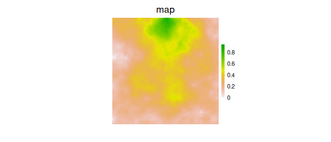

```r
clearPlot()
Plot(map)
```

# 2 Reproducible Workflow

In general, we feel that a liberal use of `Cache` will make a reusable and reproducible work flow. `shiny` apps can be made, taking advantage of `Cache`. Indeed, much of the difficulty in managing data sets and saving them for future use, can be accommodated by caching.

## 2.1 Nested Caching

- Imagine we have large model with many modules
- To run this would have a nested structure with the following functions:

```r
simInit() --> many .inputObjects calls

spades() call --> many module calls --> many event calls --> many function calls
```

Lets say we start to introduce caching to this structure. We start from the “inner” most functions that we could imaging Caching would be useful. Lets say there are some GIS operations, like `raster::projectRaster`, which operates on an input shapefile. We can Cache the `projectRaster` call to make this much faster, since it will always be the same result for a given input raster.

If we look back at our structure above, we see that we still have LOTS of places that are not Cached. That means that the `spades()` call will still spawn many module calls, and many event calls, just to get to the one `Cache(projectRaster)` call which is cached. This function will likely be called many times. This is good, but **`Cache` does take some time**. So, even if `Cache(projectRaster)` takes only 0.02 seconds, calling it hundreds of times means maybe 4 seconds. If we are doing this for many functions, then this will be too slow for some purposes.

We can start putting `Cache` all up the sequence of calls. Unfortunately, the way we use Cache at each of these levels is a bit different, so we need a slightly different approach for each.

#### 2.1.0.1 Cache the `spades` call

`spades(cache = TRUE)`

This will cache the `spades` call, causing stochasticity/randomness to be frozen.

#### 2.1.0.2 Cache a whole module

Pass `.useCache = TRUE` as a parameter to the module, during the `simInit`

Some modules are inherently non-random, such as GIS modules, or parameter fitting statistical modules. We expect these to be identical results each time, so we can safely cache the entire module.

```r
parameters = list(
  FireModule = list(.useCache = TRUE)
)
mySim <- simInit(..., params = parameters)
mySimOut <- spades(mySim)
```

The messaging should indicate the caching is happening on every event in that module.

*Note: This option REQUIRES that the metadata in inputs and outputs be exactly correct, i.e., all `inputObjects` and `outputObjects` must be correctly identified and listed in the `defineModule` metadata*

*If the module is cached, and there are errors when it is run, it almost is guaranteed to be a problem with the `inputObjects` and `outputObjects` incorrectly specified.*

#### 2.1.0.3 Cache individual functions

`Cache(<functionName>, <other arguments>)`

This will allow fine scale control of individual function calls.

## 2.2 Data-to-decisions

Once nested Caching is used all the way up to the `experiment` (see `SpaDES.experiment` package) level and even further up (e.g., if there is a `shiny` module), then even very complex models can be put into a complete workflow.

The current vision for `SpaDES` is that it will allow this type of “data to decisions” complete workflow that allows for deep, robust models, across disciplines, with easily accessible front ends, that are quick and responsive to users, yet can handle data changes, module changes, etc.